# First components of the ggspec function

**Initial plan of attack**:

Start with small, simple components to extract certain elements we need. Then work to combine these components to build the full ggspec.

**Notes**:

Still need to do quite a bit of work with the functions for the data, but I feel the functions for the layers are coming along nicely.

## Extracting elements

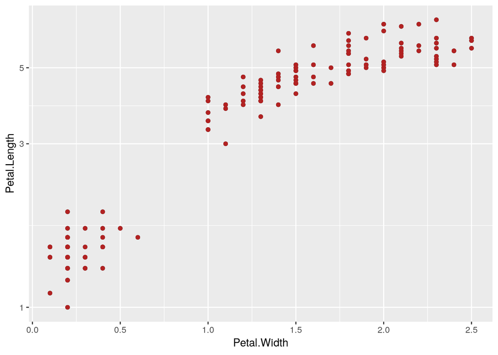

```r
p <- ggplot(iris) +
  geom_point(aes(x = Petal.Width, y = Petal.Length)) +
  geom_point(aes(x = Petal.Width, y = Petal.Length), color = "firebrick") +
  scale_y_log10()

p
```

### Extracting data

**Proposal**: Save the data at top-level and then have a reference to the appropriate data within the layers as such:

```
{
  "data": {
    "data-00": {
      "metadata": {},
      "observations": [{}, {}]
    }
  }
}
```

The first move will be to create the list `data` where all of the data will live. We create the list when extracting the default data and then add to it when dealing with the layers.

**Default data**:

```r
## How to make this applicable to multiple factors?
## How to have this only run IF a factor is detected?

create_meta <- function(dat){
  loc <- purrr::detect_index(dat, is.factor)
  levels <- purrr::pluck(dat, loc, levels)
  meta <- list(levels) ## How to evaluate the name first??
  names(meta) <- names(dat)[loc]
  meta
}

get_data_default <- function(p){
  dat00 <- purrr::pluck(p, "data")
  meta <- create_meta(dat00)
  dat00 <- list(
    observations = jsonlite::toJSON(dat00),
    metadata = meta
  )
  list(`data-00` = dat00)
}
```

```r
data <- get_data_default(p)
str(data)
```

```
## List of 1
##  $ data-00:List of 2
##   ..$ observations: 'json' chr "[{\"Sepal.Length\":5.1,\"Sepal.Width\":3.5,\"Petal.Length\":1.4,\"Petal.Width\":0.2,\"Species\":\"setosa\"},{\""| __truncated__
##   ..$ metadata    :List of 1
##   .. ..$ Species: chr [1:3] "setosa" "versicolor" "virginica"
```

**Layer data**:

(THIS NEEDS WORK)

Do we need both a `get_data_layers` that collects all data other than the default data and a `get_layer_data` which saves the reference to which data is to be used?

`get_data_layers()` should then ammend the `data` list created by the previous function.

```r
get_data_layers <- function(ind) {
  # How to add in check that it isn't NULL ??
  data[[ind+1]] <- purrr::pluck(p, "layers", ind, "data") #, .default = `data-00`)
}

## will then need to run additional functions to get name and create metadata
```

### Extracting layers

Within each layer-object, we need:  
1. data (a reference id?)  
2. geom  
3. geom_params (maybe) 4. mapping  
5. aes_params  
6. stat (maybe)  
7. stat_params (maybe)

**The data**

(THIS NEEDS WORK)

`get_layer_data()` should save an id to reference which data source from the top-level data should be used.

How to extract a name for the dataset??

```r
get_layer_data <- function(ind) {
  # How to extract a name for the dataset??
  data <- purrr::pluck(p, "layers", ind, "data", .default = "data-00")
}
```

**The geom**:

```r
get_layer_geom <- function(ind){
  list(
    class = purrr::pluck(p, "layers", ind, "geom", class)
  )
}
```

```r
str(get_layer_geom(1))
```

```
## List of 1
##  $ class: chr [1:4] "GeomPoint" "Geom" "ggproto" "gg"
```

**The geom parameters**:

**The mapping**:

```r
get_layer_mapping_vars <- function(aes, ind) {
  field = purrr::pluck(p, "layers", ind, "mapping", aes, rlang::get_expr)
  type = NULL
  list(field = field, type = type)
}

get_layer_mapping <- function(ind){
  map_names <- purrr::pluck(p, "layers", ind, "mapping", names)
  mapping <- as.list(map_names)
  names(mapping) <- map_names
  map(mapping, get_layer_mapping_vars, ind)
}
```

```r
str(get_layer_mapping(2))
```

```
## List of 2
##  $ x:List of 2
##   ..$ field: symbol Petal.Width
##   ..$ type : NULL
##  $ y:List of 2
##   ..$ field: symbol Petal.Length
##   ..$ type : NULL
```

**Question**: Do we need to save the environment with the symbol?

**The aesthetic parameters**:

```r
get_layer_aes_params <- function(ind){
  purrr::pluck(p, "layers", ind, "aes_params")
}
```

```r
str(get_layer_aes_params(2))
```

```
## List of 1
##  $ colour: chr "firebrick"
```

**The stat**:

For right now, we will just extract the class.

```r
get_layer_stat <- function(ind){
  list(
    class = purrr::pluck(p, "layers", ind, "stat", class)
  )
}
```

```r
str(get_layer_stat(2))
```

```
## List of 1
##  $ class: chr [1:4] "StatIdentity" "Stat" "ggproto" "gg"
```

**The stat parameters**:

#### Putting the layers together

```r
get_layers <- function(ind){
  list(
    data = get_layer_data(ind),
    geom = get_layer_geom(ind),
    geom_params = list(),
    mapping = get_layer_mapping(ind),
    aes_params = get_layer_aes_params(ind),
    stat = get_layer_stat(ind),
    stat_params = list()
  )
}

str(map(1:2, get_layers))
```

```
## List of 2
##  $ :List of 7
##   ..$ data       : chr "data-00"
##   ..$ geom       :List of 1
##   .. ..$ class: chr [1:4] "GeomPoint" "Geom" "ggproto" "gg"
##   ..$ geom_params: list()
##   ..$ mapping    :List of 2
##   .. ..$ x:List of 2
##   .. .. ..$ field: symbol Petal.Width
##   .. .. ..$ type : NULL
##   .. ..$ y:List of 2
##   .. .. ..$ field: symbol Petal.Length
##   .. .. ..$ type : NULL
##   ..$ aes_params : NULL
##   ..$ stat       :List of 1
##   .. ..$ class: chr [1:4] "StatIdentity" "Stat" "ggproto" "gg"
##   ..$ stat_params: list()
##  $ :List of 7
##   ..$ data       : chr "data-00"
##   ..$ geom       :List of 1
##   .. ..$ class: chr [1:4] "GeomPoint" "Geom" "ggproto" "gg"
##   ..$ geom_params: list()
##   ..$ mapping    :List of 2
##   .. ..$ x:List of 2
##   .. .. ..$ field: symbol Petal.Width
##   .. .. ..$ type : NULL
##   .. ..$ y:List of 2
##   .. .. ..$ field: symbol Petal.Length
##   .. .. ..$ type : NULL
##   ..$ aes_params :List of 1
##   .. ..$ colour: chr "firebrick"
##   ..$ stat       :List of 1
##   .. ..$ class: chr [1:4] "StatIdentity" "Stat" "ggproto" "gg"
##   ..$ stat_params: list()
```

### Extracting scales

We should note that in the plot object, scales only appear if they are specified by the user.

```r
get_scales_transform <- function(ind) {
  trans = purrr::pluck(p, "scales", "scales", ind, "trans", "transform")
  fun = rlang::fn_body(trans)
  bindings = as.list(ls(environment(trans)))
  names(bindings) <- ls(environment(trans))

  list(
    fun = fun,
    bindings = map(bindings, ~ pluck(rlang::fn_env(trans), .x))
  )

}


get_scales <- function(ind){
  list(
    class = purrr::pluck(p, "scales", "scales", ind, class),
    aesthetics = purrr::pluck(p, "scales", "scales", ind, "aesthetics"),
    transform = get_scales_transform(ind)
  )
}

str(get_scales(1))
```

```
## List of 3
##  $ class     : chr [1:5] "ScaleContinuousPosition" "ScaleContinuous" "Scale" "ggproto" ...
##  $ aesthetics: chr [1:10] "y" "ymin" "ymax" "yend" ...
##  $ transform :List of 2
##   ..$ fun     : language {  log(x, base) }
##   ..$ bindings:List of 3
##   .. ..$ base : num 10
##   .. ..$ inv  :function (x)
##   .. ..$ trans:function (x)
```

### Extracting labels

```r
get_labels <- function(p){
  purrr::pluck(p, "labels")
}


get_labels(p)
```

```
## $x
## [1] "Petal.Width"
##
## $y
## [1] "Petal.Length"
```

## Creating the spec

```r
gg2spec <- function(p){

  n_layers <- length(p$layers)
  n_scales <- length(p$scales$scales)

  list(
    data = get_data_default(p),
    layers = map(seq_along(1:n_layers), get_layers),
    scales = map(seq_along(1:n_scales), get_scales),
    labels = get_labels(p)
  )
}
```

```r
p_spec <- gg2spec(p)
str(p_spec)
```

```
## List of 4
##  $ data  :List of 1
##   ..$ data-00:List of 2
##   .. ..$ observations: 'json' chr "[{\"Sepal.Length\":5.1,\"Sepal.Width\":3.5,\"Petal.Length\":1.4,\"Petal.Width\":0.2,\"Species\":\"setosa\"},{\""| __truncated__
##   .. ..$ metadata    :List of 1
##   .. .. ..$ Species: chr [1:3] "setosa" "versicolor" "virginica"
##  $ layers:List of 2
##   ..$ :List of 7
##   .. ..$ data       : chr "data-00"
##   .. ..$ geom       :List of 1
##   .. .. ..$ class: chr [1:4] "GeomPoint" "Geom" "ggproto" "gg"
##   .. ..$ geom_params: list()
##   .. ..$ mapping    :List of 2
##   .. .. ..$ x:List of 2
##   .. .. .. ..$ field: symbol Petal.Width
##   .. .. .. ..$ type : NULL
##   .. .. ..$ y:List of 2
##   .. .. .. ..$ field: symbol Petal.Length
##   .. .. .. ..$ type : NULL
##   .. ..$ aes_params : NULL
##   .. ..$ stat       :List of 1
##   .. .. ..$ class: chr [1:4] "StatIdentity" "Stat" "ggproto" "gg"
##   .. ..$ stat_params: list()
##   ..$ :List of 7
##   .. ..$ data       : chr "data-00"
##   .. ..$ geom       :List of 1
##   .. .. ..$ class: chr [1:4] "GeomPoint" "Geom" "ggproto" "gg"
##   .. ..$ geom_params: list()
##   .. ..$ mapping    :List of 2
##   .. .. ..$ x:List of 2
##   .. .. .. ..$ field: symbol Petal.Width
##   .. .. .. ..$ type : NULL
##   .. .. ..$ y:List of 2
##   .. .. .. ..$ field: symbol Petal.Length
##   .. .. .. ..$ type : NULL
##   .. ..$ aes_params :List of 1
##   .. .. ..$ colour: chr "firebrick"
##   .. ..$ stat       :List of 1
##   .. .. ..$ class: chr [1:4] "StatIdentity" "Stat" "ggproto" "gg"
##   .. ..$ stat_params: list()
##  $ scales:List of 1
##   ..$ :List of 3
##   .. ..$ class     : chr [1:5] "ScaleContinuousPosition" "ScaleContinuous" "Scale" "ggproto" ...
##   .. ..$ aesthetics: chr [1:10] "y" "ymin" "ymax" "yend" ...
##   .. ..$ transform :List of 2
##   .. .. ..$ fun     : language {  log(x, base) }
##   .. .. ..$ bindings:List of 3
##   .. .. .. ..$ base : num 10
##   .. .. .. ..$ inv  :function (x)
##   .. .. .. ..$ trans:function (x)
##  $ labels:List of 2
##   ..$ x: chr "Petal.Width"
##   ..$ y: chr "Petal.Length"
```